# Illini Esports Engagement

# Growth and Activation

```r
join = read.csv("guild-activation.csv")
join
```

| interval_start_timestamp | new_members | pct_communicated | pct_opened_channels |
| --- | --- | --- | --- |
| 2019-03-29T00:00:00+00:00 | 2 | 50.000000 | 50.00000 |
| 2019-03-30T00:00:00+00:00 | 6 | 16.666667 | 33.33333 |
| 2019-03-31T00:00:00+00:00 | 8 | 25.000000 | 37.50000 |
| 2019-04-01T00:00:00+00:00 | 9 | 44.444444 | 33.33333 |
| 2019-04-02T00:00:00+00:00 | 2 | 50.000000 | 100.00000 |
| 2019-04-03T00:00:00+00:00 | 0 | NA | NA |
| 2019-04-04T00:00:00+00:00 | 2 | 100.000000 | 100.00000 |
| 2019-04-05T00:00:00+00:00 | 3 | 33.333333 | 0.00000 |
| 2019-04-06T00:00:00+00:00 | 2 | 0.000000 | 0.00000 |
| 2019-04-07T00:00:00+00:00 | 2 | 0.000000 | 0.00000 |

[output cut: 719 more lines]

```r
leave = read.csv("guild-leavers.csv")
leave
```

| interval_start_timestamp | days_in_guild | leavers |
| --- | --- | --- |
| 2019-03-29T00:00:00+00:00 | 'Members for 1 month+' | 1 |
| 2019-03-30T00:00:00+00:00 | 'Members for 1 month+' | 1 |
| 2019-03-30T00:00:00+00:00 | 'Members for < 1 month' | 1 |
| 2019-03-31T00:00:00+00:00 | 'Members for 1 month+' | 2 |
| 2019-03-31T00:00:00+00:00 | 'Members for < 1 month' | 1 |
| 2019-04-01T00:00:00+00:00 | 'Members for 1 month+' | 4 |
| 2019-04-02T00:00:00+00:00 | 'Members for 1 month+' | 1 |
| 2019-04-03T00:00:00+00:00 | 'Members for 1 month+' | 2 |
| 2019-04-03T00:00:00+00:00 | 'Members for < 1 month' | 2 |
| 2019-04-04T00:00:00+00:00 | 'Members for 1 month+' | 2 |

[output cut: 990 more lines]

```r
source = read.csv("guild-joins-by-source.csv")
source
```

| interval_start_timestamp | discovery_joins | invites | vanity_joins |
| --- | --- | --- | --- |
| 2019-03-29T00:00:00+00:00 | 0 | 0 | 3 |
| 2019-03-30T00:00:00+00:00 | 0 | 0 | 7 |
| 2019-03-31T00:00:00+00:00 | 0 | 0 | 8 |
| 2019-04-01T00:00:00+00:00 | 0 | 0 | 11 |
| 2019-04-02T00:00:00+00:00 | 0 | 0 | 2 |
| 2019-04-03T00:00:00+00:00 | 0 | 0 | 1 |
| 2019-04-04T00:00:00+00:00 | 0 | 0 | 3 |
| 2019-04-05T00:00:00+00:00 | 0 | 0 | 4 |
| 2019-04-06T00:00:00+00:00 | 0 | 0 | 3 |
| 2019-04-07T00:00:00+00:00 | 0 | 0 | 2 |

[output cut: 719 more lines]

# Engagement by channels

```r
text = read.csv("popular-text-channels.csv")
text
```

| interval_start_timestamp | channel_name | channel_id | readers | chatters | messages |
| --- | --- | --- | --- | --- | --- |
| 2021-03-27T00:00:00+00:00 | general | 2.124359e+17 | 218 | 51 | 264 |
| 2021-03-27T00:00:00+00:00 | hearthstone | 2.124361e+17 | 3 | 0 | 0 |
| 2021-03-27T00:00:00+00:00 | overwatch | 2.124362e+17 | 98 | 38 | 794 |
| 2021-03-27T00:00:00+00:00 | lol | 2.124362e+17 | 97 | 31 | 181 |
| 2021-03-27T00:00:00+00:00 | csgo | 2.124363e+17 | 29 | 4 | 5 |
| 2021-03-27T00:00:00+00:00 | dota2 | 2.124364e+17 | 17 | 5 | 11 |
| 2021-03-27T00:00:00+00:00 | announcements | 2.124422e+17 | 880 | 1 | 4 |
| 2021-03-27T00:00:00+00:00 | other-games | 2.127412e+17 | 46 | 7 | 13 |
| 2021-03-27T00:00:00+00:00 | suggestions | 2.130108e+17 | 27 | 4 | 5 |
| 2021-03-27T00:00:00+00:00 | memes | 2.170801e+17 | 71 | 11 | 36 |

[output cut: 82 more lines]

```r
voice = read.csv("popular-voice-channels.csv")
voice
```

| interval_start_timestamp | channel_name | channel_id | listeners | communicators |
| --- | --- | --- | --- | --- |
| 2021-03-27T00:00:00+00:00 | AFK Channel | 2.559102e+17 | 7 | 0 |
| 2021-03-27T00:00:00+00:00 | Overwatch Oasis | 2.617080e+17 | 17 | 16 |
| 2021-03-27T00:00:00+00:00 | LoL In-House Lobby | 2.834215e+17 | 2 | 2 |
| 2021-03-27T00:00:00+00:00 | Overwatch Room 1 | 3.533817e+17 | 17 | 16 |
| 2021-03-27T00:00:00+00:00 | General Gaming | 5.960341e+17 | 10 | 10 |
| 2021-03-27T00:00:00+00:00 | Music Channel | 5.960341e+17 | 2 | 3 |
| 2021-03-27T00:00:00+00:00 | Overwatch Room 2 | 6.000934e+17 | 14 | 14 |
| 2021-03-27T00:00:00+00:00 | Throwstack Oasis | 6.153540e+17 | 14 | 14 |
| 2021-03-27T00:00:00+00:00 | Valorant Haven | 6.958620e+17 | 3 | 3 |
| 2021-03-27T00:00:00+00:00 | Social Gaming | 6.960872e+17 | 15 | 14 |

[output cut: 2 more lines]

```r
communicator = read.csv("guild-communicators.csv")
communicator
```

| interval_start_timestamp | visitors | pct_communicated |
| --- | --- | --- |
| 2019-03-29T00:00:00+00:00 | 206 | 25.728155 |
| 2019-03-30T00:00:00+00:00 | 184 | 20.652174 |
| 2019-03-31T00:00:00+00:00 | 185 | 24.324324 |
| 2019-04-01T00:00:00+00:00 | 328 | 22.865854 |
| 2019-04-02T00:00:00+00:00 | 143 | 33.566434 |
| 2019-04-03T00:00:00+00:00 | 271 | 16.605166 |
| 2019-04-04T00:00:00+00:00 | 381 | 13.385827 |
| 2019-04-05T00:00:00+00:00 | 190 | 24.736842 |
| 2019-04-06T00:00:00+00:00 | 163 | 26.993865 |
| 2019-04-07T00:00:00+00:00 | 159 | 31.446541 |

[output cut: 719 more lines]

# ETL on Growth and Activation

## messing around with date time

### library

```r
library(lubridate)
```

### datetime example

I grabbed this example from [astrostats.psu](https://astrostatistics.psu.edu/su07/R/html/base/html/format.Date.html)

```r
## read in date/time info in format 'm/d/y h:m:s'
dates <- c("02/27/92", "02/27/92", "01/14/92", "02/28/92", "02/01/92")
times <- c("23:03:20", "22:29:56", "01:03:30", "18:21:03", "16:56:26")
x <- paste(dates, times)
strptime(x, "%m/%d/%y %H:%M:%S")
```

```
[1] "1992-02-27 23:03:20 CST" "1992-02-27 22:29:56 CST" "1992-01-14 01:03:30 CST" "1992-02-28 18:21:03 CST"
[5] "1992-02-01 16:56:26 CST"
```

```r
strptime(x, "%m/")
```

```
[1] NA NA NA NA NA
```

### tests to investigate how to extract date time

These were scuffed tests I used to learn how to extract the date time * the variable `test` made me realize removing `+00:00` and replacing it with a `Z` would make the data in a format that can be read by R * the variable `test2` was my attempt to try getting it for an entire column

```r
test = "2021-03-27T00:00:00Z"
str(ymd_hms(test))
```

```
 POSIXct[1:1], format: "2021-03-27"
```

```r
test2 = join$interval_start_timestamp
#test2
#ymd_hms(join$interval_start_timestamp)

#strptime(test2, "%Y-%m-%dT%H:%M:%SZ")
```

While performing my tests, I struggled understanding format of the date was in, a search of a [2021-03-27T00:00:00+00:00 datatype](https://duckduckgo.com/?q=2021-03-27T00%3A00%3A00%2B00%3A00+datatype&t=ffab&ia=web) pointed me to a stack overflow page that helped me learn more about python functions [Date Time Formats in Python](https://stackoverflow.com/questions/17594298/date-time-formats-in-python).

### testing substring removal

- with a understanding of what I needed to make it possible, I moved on to learn about substring replacement. This took a long time to figure out and understand.

#### removing the plus sign

a search of [R remove all text after plus sign](https://duckduckgo.com/?q=R+remove+all+text+after+plus+sign&t=ffab&ia=web) helped me break through this barrier I found that this answer on stackoverflow was particularly helpful in removing the `+` sign [How to remove + (plus sign) from string in R?](https://stackoverflow.com/a/35807737)

#### removing the rest of zeros

I found the following stackoverflow answer that had a example for how to remove the rest of a string [Remove all text before colon](https://stackoverflow.com/a/12297991)

```r
gsub("\\+.*", 'Z', "2021-03-27T00:00:00+00:00")
```

```
[1] "2021-03-27T00:00:00Z"
```

## removing +00:00 from the whole column

these were tests I ran to automate this for all the datetime rows

```r
#join[1,1] = gsub("\\+.*", 'Z', join[1,1])
#join

join[,1] = gsub("\\+.*", 'Z', join[,1])
join
```

| interval_start_timestamp | new_members | pct_communicated | pct_opened_channels |
| --- | --- | --- | --- |
| 2019-03-29T00:00:00Z | 2 | 50.000000 | 50.00000 |
| 2019-03-30T00:00:00Z | 6 | 16.666667 | 33.33333 |
| 2019-03-31T00:00:00Z | 8 | 25.000000 | 37.50000 |
| 2019-04-01T00:00:00Z | 9 | 44.444444 | 33.33333 |
| 2019-04-02T00:00:00Z | 2 | 50.000000 | 100.00000 |
| 2019-04-03T00:00:00Z | 0 | NA | NA |
| 2019-04-04T00:00:00Z | 2 | 100.000000 | 100.00000 |
| 2019-04-05T00:00:00Z | 3 | 33.333333 | 0.00000 |
| 2019-04-06T00:00:00Z | 2 | 0.000000 | 0.00000 |
| 2019-04-07T00:00:00Z | 2 | 0.000000 | 0.00000 |

[output cut: 719 more lines]

```r
NA
```

### split the `interval_start_timestamp`

Once I got it working on a row, I applied what I learned above to extract the year, month, and day from the initial datetime object Later when I was generating the bar charts, I had issues ordering the data by calendar months, a quick search yielded [Sorting months in R](https://stackoverflow.com/a/9769735) I learned that passing `months` into `factor` with the `levels = month.name` would allow me to sort by the months

```r
year = year(as.POSIXlt(join$interval_start_timestamp))

month = factor(months(as.POSIXlt(join$interval_start_timestamp)),levels = month.name)

day = weekdays(as.POSIXlt(join$interval_start_timestamp))
```

## make the new dataframe

After making the split dataframes, I used a cbind to append the columns to the original dataset and reordered the dataset.

```r
joins = cbind(join, year, month,day)
joins
```

| interval_start_timestamp | new_members | pct_communicated | pct_opened_channels | year | month | day |
| --- | --- | --- | --- | --- | --- | --- |
| 2019-03-29T00:00:00Z | 2 | 50.000000 | 50.00000 | 2019 | March | Friday |
| 2019-03-30T00:00:00Z | 6 | 16.666667 | 33.33333 | 2019 | March | Saturday |
| 2019-03-31T00:00:00Z | 8 | 25.000000 | 37.50000 | 2019 | March | Sunday |
| 2019-04-01T00:00:00Z | 9 | 44.444444 | 33.33333 | 2019 | April | Monday |
| 2019-04-02T00:00:00Z | 2 | 50.000000 | 100.00000 | 2019 | April | Tuesday |
| 2019-04-03T00:00:00Z | 0 | NA | NA | 2019 | April | Wednesday |
| 2019-04-04T00:00:00Z | 2 | 100.000000 | 100.00000 | 2019 | April | Thursday |
| 2019-04-05T00:00:00Z | 3 | 33.333333 | 0.00000 | 2019 | April | Friday |
| 2019-04-06T00:00:00Z | 2 | 0.000000 | 0.00000 | 2019 | April | Saturday |
| 2019-04-07T00:00:00Z | 2 | 0.000000 | 0.00000 | 2019 | April | Sunday |

[output cut: 719 more lines]

```r
joins = joins[,c(1,5,6,7,2,3,4)]
joins
```

| interval_start_timestamp | year | month | day | new_members | pct_communicated | pct_opened_channels |
| --- | --- | --- | --- | --- | --- | --- |
| 2019-03-29T00:00:00Z | 2019 | March | Friday | 2 | 50.000000 | 50.00000 |
| 2019-03-30T00:00:00Z | 2019 | March | Saturday | 6 | 16.666667 | 33.33333 |
| 2019-03-31T00:00:00Z | 2019 | March | Sunday | 8 | 25.000000 | 37.50000 |
| 2019-04-01T00:00:00Z | 2019 | April | Monday | 9 | 44.444444 | 33.33333 |
| 2019-04-02T00:00:00Z | 2019 | April | Tuesday | 2 | 50.000000 | 100.00000 |
| 2019-04-03T00:00:00Z | 2019 | April | Wednesday | 0 | NA | NA |
| 2019-04-04T00:00:00Z | 2019 | April | Thursday | 2 | 100.000000 | 100.00000 |
| 2019-04-05T00:00:00Z | 2019 | April | Friday | 3 | 33.333333 | 0.00000 |
| 2019-04-06T00:00:00Z | 2019 | April | Saturday | 2 | 0.000000 | 0.00000 |
| 2019-04-07T00:00:00Z | 2019 | April | Sunday | 2 | 0.000000 | 0.00000 |

[output cut: 719 more lines]

## Extracting date time

run the following cell to extract year, month, day

```r
factor(months(as.POSIXlt(join$interval_start_timestamp)),levels = month.name)
```

```
  [1] March     March     March     April     April     April     April     April     April     April
 [11] April     April     April     April     April     April     April     April     April     April
 [21] April     April     April     April     April     April     April     April     April     April
 [31] April     April     April     May       May       May       May       May       May       May
 [41] May       May       May       May       May       May       May       May       May       May
 [51] May       May       May       May       May       May       May       May       May       May
 [61] May       May       May       May       June      June      June      June      June      June
 [71] June      June      June      June      June      June      June      June      June      June
 [81] June      June      June      June      June      June      June      June      June      June
 [91] June      June      June      June      July      July      July      July      July      July
[101] July      July      July      July      July      July      July      July      July      July
[111] July      July      July      July      July      July      July      July      July      July
[121] July      July      July      July      July      August    August    August    August    August
[131] August    August    August    August    August    August    August    August    August    August
[141] August    August    August    August    August    August    August    August    August    August
```

[output cut: 59 more lines]

```r
# substring replacement
join[,1] = gsub("\\+.*", 'Z', join[,1])

# individual extraction
year = factor(year(as.POSIXlt(join[,1])))
month = factor(months(as.POSIXlt(join[,1])),levels = month.name)
day = weekdays(as.POSIXlt(join[,1]))

# appending new indivually extracted dates
joins = cbind(join, year, month,day)
joins = joins[,c(1,5,6,7,2,3,4)]
joins
```

| interval_start_timestamp | year | month | day | new_members | pct_communicated | pct_opened_channels |
| --- | --- | --- | --- | --- | --- | --- |
| 2019-03-29T00:00:00Z | 2019 | March | Friday | 2 | 50.000000 | 50.00000 |
| 2019-03-30T00:00:00Z | 2019 | March | Saturday | 6 | 16.666667 | 33.33333 |
| 2019-03-31T00:00:00Z | 2019 | March | Sunday | 8 | 25.000000 | 37.50000 |
| 2019-04-01T00:00:00Z | 2019 | April | Monday | 9 | 44.444444 | 33.33333 |
| 2019-04-02T00:00:00Z | 2019 | April | Tuesday | 2 | 50.000000 | 100.00000 |
| 2019-04-03T00:00:00Z | 2019 | April | Wednesday | 0 | NA | NA |
| 2019-04-04T00:00:00Z | 2019 | April | Thursday | 2 | 100.000000 | 100.00000 |
| 2019-04-05T00:00:00Z | 2019 | April | Friday | 3 | 33.333333 | 0.00000 |
| 2019-04-06T00:00:00Z | 2019 | April | Saturday | 2 | 0.000000 | 0.00000 |
| 2019-04-07T00:00:00Z | 2019 | April | Sunday | 2 | 0.000000 | 0.00000 |

[output cut: 719 more lines]

```r
# substring replacement
leave[,1] = gsub("\\+.*", 'Z', leave[,1])

# individual extraction
year = factor(year(as.POSIXlt(leave[,1])))
month = factor(months(as.POSIXlt(leave[,1])),levels = month.name)
day = weekdays(as.POSIXlt(leave[,1]))

# appending new indivually extracted dates
leaves = cbind(leave, year, month,day)
leaves = leaves[,c(1,4,5,6,2,3)]
leaves
```

| interval_start_timestamp | year | month | day | days_in_guild | leavers |
| --- | --- | --- | --- | --- | --- |
| 2019-03-29T00:00:00Z | 2019 | March | Friday | 'Members for 1 month+' | 1 |
| 2019-03-30T00:00:00Z | 2019 | March | Saturday | 'Members for 1 month+' | 1 |
| 2019-03-30T00:00:00Z | 2019 | March | Saturday | 'Members for < 1 month' | 1 |
| 2019-03-31T00:00:00Z | 2019 | March | Sunday | 'Members for 1 month+' | 2 |
| 2019-03-31T00:00:00Z | 2019 | March | Sunday | 'Members for < 1 month' | 1 |
| 2019-04-01T00:00:00Z | 2019 | April | Monday | 'Members for 1 month+' | 4 |
| 2019-04-02T00:00:00Z | 2019 | April | Tuesday | 'Members for 1 month+' | 1 |
| 2019-04-03T00:00:00Z | 2019 | April | Wednesday | 'Members for 1 month+' | 2 |
| 2019-04-03T00:00:00Z | 2019 | April | Wednesday | 'Members for < 1 month' | 2 |
| 2019-04-04T00:00:00Z | 2019 | April | Thursday | 'Members for 1 month+' | 2 |

[output cut: 990 more lines]

```r
# substring replacement
source[,1] = gsub("\\+.*", 'Z', source[,1])

# individual extraction
year = factor(year(as.POSIXlt(source[,1])))
month = factor(months(as.POSIXlt(source[,1])),levels = month.name)
day = weekdays(as.POSIXlt(source[,1]))

# appending new indivually extracted dates
sources = cbind(source, year, month,day)
sources = sources[,c(1,5,6,7,2,3,4)]
sources
```

| interval_start_timestamp | year | month | day | discovery_joins | invites | vanity_joins |
| --- | --- | --- | --- | --- | --- | --- |
| 2019-03-29T00:00:00Z | 2019 | March | Friday | 0 | 0 | 3 |
| 2019-03-30T00:00:00Z | 2019 | March | Saturday | 0 | 0 | 7 |
| 2019-03-31T00:00:00Z | 2019 | March | Sunday | 0 | 0 | 8 |
| 2019-04-01T00:00:00Z | 2019 | April | Monday | 0 | 0 | 11 |
| 2019-04-02T00:00:00Z | 2019 | April | Tuesday | 0 | 0 | 2 |
| 2019-04-03T00:00:00Z | 2019 | April | Wednesday | 0 | 0 | 1 |
| 2019-04-04T00:00:00Z | 2019 | April | Thursday | 0 | 0 | 3 |
| 2019-04-05T00:00:00Z | 2019 | April | Friday | 0 | 0 | 4 |
| 2019-04-06T00:00:00Z | 2019 | April | Saturday | 0 | 0 | 3 |
| 2019-04-07T00:00:00Z | 2019 | April | Sunday | 0 | 0 | 2 |

[output cut: 719 more lines]

```r
# substring replacement
communicator[,1] = gsub("\\+.*", 'Z', communicator[,1])

# individual extraction
year = factor(year(as.POSIXlt(communicator[,1])))
month = factor(months(as.POSIXlt(communicator[,1])),levels = month.name)
day = weekdays(as.POSIXlt(communicator[,1]))

# appending new indivually extracted dates
communicators = cbind(communicator, year, month,day)
communicators = communicators[,c(1,4,5,6,2,3)]
communicators$total_communicated = communicators$visitors * communicators$pct_communicated/100
communicators
```

| interval_start_timestamp | year | month | day | visitors | pct_communicated | total_communicated |
| --- | --- | --- | --- | --- | --- | --- |
| 2019-03-29T00:00:00Z | 2019 | March | Friday | 206 | 25.728155 | 53 |
| 2019-03-30T00:00:00Z | 2019 | March | Saturday | 184 | 20.652174 | 38 |
| 2019-03-31T00:00:00Z | 2019 | March | Sunday | 185 | 24.324324 | 45 |
| 2019-04-01T00:00:00Z | 2019 | April | Monday | 328 | 22.865854 | 75 |
| 2019-04-02T00:00:00Z | 2019 | April | Tuesday | 143 | 33.566434 | 48 |
| 2019-04-03T00:00:00Z | 2019 | April | Wednesday | 271 | 16.605166 | 45 |
| 2019-04-04T00:00:00Z | 2019 | April | Thursday | 381 | 13.385827 | 51 |
| 2019-04-05T00:00:00Z | 2019 | April | Friday | 190 | 24.736842 | 47 |
| 2019-04-06T00:00:00Z | 2019 | April | Saturday | 163 | 26.993865 | 44 |
| 2019-04-07T00:00:00Z | 2019 | April | Sunday | 159 | 31.446541 | 50 |

[output cut: 719 more lines]

# data needed for investigation

```r
joins
```

| interval_start_timestamp | year | month | day | new_members | pct_communicated | pct_opened_channels |
| --- | --- | --- | --- | --- | --- | --- |
| 2019-03-29T00:00:00Z | 2019 | March | Friday | 2 | 50.000000 | 50.00000 |
| 2019-03-30T00:00:00Z | 2019 | March | Saturday | 6 | 16.666667 | 33.33333 |
| 2019-03-31T00:00:00Z | 2019 | March | Sunday | 8 | 25.000000 | 37.50000 |
| 2019-04-01T00:00:00Z | 2019 | April | Monday | 9 | 44.444444 | 33.33333 |
| 2019-04-02T00:00:00Z | 2019 | April | Tuesday | 2 | 50.000000 | 100.00000 |
| 2019-04-03T00:00:00Z | 2019 | April | Wednesday | 0 | NA | NA |
| 2019-04-04T00:00:00Z | 2019 | April | Thursday | 2 | 100.000000 | 100.00000 |
| 2019-04-05T00:00:00Z | 2019 | April | Friday | 3 | 33.333333 | 0.00000 |
| 2019-04-06T00:00:00Z | 2019 | April | Saturday | 2 | 0.000000 | 0.00000 |
| 2019-04-07T00:00:00Z | 2019 | April | Sunday | 2 | 0.000000 | 0.00000 |

[output cut: 719 more lines]

```r
leaves
```

| interval_start_timestamp | year | month | day | days_in_guild | leavers |
| --- | --- | --- | --- | --- | --- |
| 2019-03-29T00:00:00Z | 2019 | March | Friday | 'Members for 1 month+' | 1 |
| 2019-03-30T00:00:00Z | 2019 | March | Saturday | 'Members for 1 month+' | 1 |
| 2019-03-30T00:00:00Z | 2019 | March | Saturday | 'Members for < 1 month' | 1 |
| 2019-03-31T00:00:00Z | 2019 | March | Sunday | 'Members for 1 month+' | 2 |
| 2019-03-31T00:00:00Z | 2019 | March | Sunday | 'Members for < 1 month' | 1 |
| 2019-04-01T00:00:00Z | 2019 | April | Monday | 'Members for 1 month+' | 4 |
| 2019-04-02T00:00:00Z | 2019 | April | Tuesday | 'Members for 1 month+' | 1 |
| 2019-04-03T00:00:00Z | 2019 | April | Wednesday | 'Members for 1 month+' | 2 |
| 2019-04-03T00:00:00Z | 2019 | April | Wednesday | 'Members for < 1 month' | 2 |
| 2019-04-04T00:00:00Z | 2019 | April | Thursday | 'Members for 1 month+' | 2 |

[output cut: 990 more lines]

```r
sources
```

| interval_start_timestamp | year | month | day | discovery_joins | invites | vanity_joins |
| --- | --- | --- | --- | --- | --- | --- |
| 2019-03-29T00:00:00Z | 2019 | March | Friday | 0 | 0 | 3 |
| 2019-03-30T00:00:00Z | 2019 | March | Saturday | 0 | 0 | 7 |
| 2019-03-31T00:00:00Z | 2019 | March | Sunday | 0 | 0 | 8 |
| 2019-04-01T00:00:00Z | 2019 | April | Monday | 0 | 0 | 11 |
| 2019-04-02T00:00:00Z | 2019 | April | Tuesday | 0 | 0 | 2 |
| 2019-04-03T00:00:00Z | 2019 | April | Wednesday | 0 | 0 | 1 |
| 2019-04-04T00:00:00Z | 2019 | April | Thursday | 0 | 0 | 3 |
| 2019-04-05T00:00:00Z | 2019 | April | Friday | 0 | 0 | 4 |
| 2019-04-06T00:00:00Z | 2019 | April | Saturday | 0 | 0 | 3 |
| 2019-04-07T00:00:00Z | 2019 | April | Sunday | 0 | 0 | 2 |

[output cut: 719 more lines]

```r
text
```

| interval_start_timestamp | channel_name | channel_id | readers | chatters | messages |
| --- | --- | --- | --- | --- | --- |
| 2021-03-27T00:00:00+00:00 | general | 2.124359e+17 | 218 | 51 | 264 |
| 2021-03-27T00:00:00+00:00 | hearthstone | 2.124361e+17 | 3 | 0 | 0 |
| 2021-03-27T00:00:00+00:00 | overwatch | 2.124362e+17 | 98 | 38 | 794 |
| 2021-03-27T00:00:00+00:00 | lol | 2.124362e+17 | 97 | 31 | 181 |
| 2021-03-27T00:00:00+00:00 | csgo | 2.124363e+17 | 29 | 4 | 5 |
| 2021-03-27T00:00:00+00:00 | dota2 | 2.124364e+17 | 17 | 5 | 11 |
| 2021-03-27T00:00:00+00:00 | announcements | 2.124422e+17 | 880 | 1 | 4 |
| 2021-03-27T00:00:00+00:00 | other-games | 2.127412e+17 | 46 | 7 | 13 |
| 2021-03-27T00:00:00+00:00 | suggestions | 2.130108e+17 | 27 | 4 | 5 |
| 2021-03-27T00:00:00+00:00 | memes | 2.170801e+17 | 71 | 11 | 36 |

[output cut: 82 more lines]

```r
voice
```

| interval_start_timestamp | channel_name | channel_id | listeners | communicators |
| --- | --- | --- | --- | --- |
| 2021-03-27T00:00:00+00:00 | AFK Channel | 2.559102e+17 | 7 | 0 |
| 2021-03-27T00:00:00+00:00 | Overwatch Oasis | 2.617080e+17 | 17 | 16 |
| 2021-03-27T00:00:00+00:00 | LoL In-House Lobby | 2.834215e+17 | 2 | 2 |
| 2021-03-27T00:00:00+00:00 | Overwatch Room 1 | 3.533817e+17 | 17 | 16 |
| 2021-03-27T00:00:00+00:00 | General Gaming | 5.960341e+17 | 10 | 10 |
| 2021-03-27T00:00:00+00:00 | Music Channel | 5.960341e+17 | 2 | 3 |
| 2021-03-27T00:00:00+00:00 | Overwatch Room 2 | 6.000934e+17 | 14 | 14 |
| 2021-03-27T00:00:00+00:00 | Throwstack Oasis | 6.153540e+17 | 14 | 14 |
| 2021-03-27T00:00:00+00:00 | Valorant Haven | 6.958620e+17 | 3 | 3 |
| 2021-03-27T00:00:00+00:00 | Social Gaming | 6.960872e+17 | 15 | 14 |

[output cut: 2 more lines]

```r
communicators
```

| interval_start_timestamp | year | month | day | visitors | pct_communicated |
| --- | --- | --- | --- | --- | --- |
| 2019-03-29T00:00:00Z | 2019 | March | Friday | 206 | 25.728155 |
| 2019-03-30T00:00:00Z | 2019 | March | Saturday | 184 | 20.652174 |
| 2019-03-31T00:00:00Z | 2019 | March | Sunday | 185 | 24.324324 |
| 2019-04-01T00:00:00Z | 2019 | April | Monday | 328 | 22.865854 |
| 2019-04-02T00:00:00Z | 2019 | April | Tuesday | 143 | 33.566434 |
| 2019-04-03T00:00:00Z | 2019 | April | Wednesday | 271 | 16.605166 |
| 2019-04-04T00:00:00Z | 2019 | April | Thursday | 381 | 13.385827 |
| 2019-04-05T00:00:00Z | 2019 | April | Friday | 190 | 24.736842 |
| 2019-04-06T00:00:00Z | 2019 | April | Saturday | 163 | 26.993865 |
| 2019-04-07T00:00:00Z | 2019 | April | Sunday | 159 | 31.446541 |

[output cut: 719 more lines]

# extracting by year

```r
joins.2019 = subset(joins, year == 2019)
joins.2020 = subset(joins, year == 2020)
joins.2021 = subset(joins, year == 2021)

leaves.2019 = subset(leaves, year == 2019)
leaves.2020 = subset(leaves, year == 2020)
leaves.2021 = subset(leaves, year == 2021)

sources.2019 = subset(sources, year == 2019)
sources.2020 = subset(sources, year == 2020)
sources.2021 = subset(sources, year == 2021)

comm.2019 = subset(communicators, year == 2019)
comm.2020 = subset(communicators, year == 2020)
comm.2021 = subset(communicators, year == 2021)
```

# investigating each year

## 2019

```r
joins.2019
```

|  | interval_start_timestamp | year | month | day | new_members | pct_communicated | pct_opened_channels |
| --- | --- | --- | --- | --- | --- | --- | --- |
| 1 | 2019-03-29T00:00:00Z | 2019 | March | Friday | 2 | 50.000000 | 50.00000 |
| 2 | 2019-03-30T00:00:00Z | 2019 | March | Saturday | 6 | 16.666667 | 33.33333 |
| 3 | 2019-03-31T00:00:00Z | 2019 | March | Sunday | 8 | 25.000000 | 37.50000 |
| 4 | 2019-04-01T00:00:00Z | 2019 | April | Monday | 9 | 44.444444 | 33.33333 |
| 5 | 2019-04-02T00:00:00Z | 2019 | April | Tuesday | 2 | 50.000000 | 100.00000 |
| 6 | 2019-04-03T00:00:00Z | 2019 | April | Wednesday | 0 | NA | NA |
| 7 | 2019-04-04T00:00:00Z | 2019 | April | Thursday | 2 | 100.000000 | 100.00000 |
| 8 | 2019-04-05T00:00:00Z | 2019 | April | Friday | 3 | 33.333333 | 0.00000 |
| 9 | 2019-04-06T00:00:00Z | 2019 | April | Saturday | 2 | 0.000000 | 0.00000 |
| 10 | 2019-04-07T00:00:00Z | 2019 | April | Sunday | 2 | 0.000000 | 0.00000 |

[output cut: 268 more lines]

```r
leaves.2019
```

|  | interval_start_timestamp | year | month | day | days_in_guild | leavers |
| --- | --- | --- | --- | --- | --- | --- |
| 1 | 2019-03-29T00:00:00Z | 2019 | March | Friday | 'Members for 1 month+' | 1 |
| 2 | 2019-03-30T00:00:00Z | 2019 | March | Saturday | 'Members for 1 month+' | 1 |
| 3 | 2019-03-30T00:00:00Z | 2019 | March | Saturday | 'Members for < 1 month' | 1 |
| 4 | 2019-03-31T00:00:00Z | 2019 | March | Sunday | 'Members for 1 month+' | 2 |
| 5 | 2019-03-31T00:00:00Z | 2019 | March | Sunday | 'Members for < 1 month' | 1 |
| 6 | 2019-04-01T00:00:00Z | 2019 | April | Monday | 'Members for 1 month+' | 4 |
| 7 | 2019-04-02T00:00:00Z | 2019 | April | Tuesday | 'Members for 1 month+' | 1 |
| 8 | 2019-04-03T00:00:00Z | 2019 | April | Wednesday | 'Members for 1 month+' | 2 |
| 9 | 2019-04-03T00:00:00Z | 2019 | April | Wednesday | 'Members for < 1 month' | 2 |
| 10 | 2019-04-04T00:00:00Z | 2019 | April | Thursday | 'Members for 1 month+' | 2 |

[output cut: 391 more lines]

```r
sources.2019
```

|  | interval_start_timestamp | year | month | day | discovery_joins | invites | vanity_joins |
| --- | --- | --- | --- | --- | --- | --- | --- |
| 1 | 2019-03-29T00:00:00Z | 2019 | March | Friday | 0 | 0 | 3 |
| 2 | 2019-03-30T00:00:00Z | 2019 | March | Saturday | 0 | 0 | 7 |
| 3 | 2019-03-31T00:00:00Z | 2019 | March | Sunday | 0 | 0 | 8 |
| 4 | 2019-04-01T00:00:00Z | 2019 | April | Monday | 0 | 0 | 11 |
| 5 | 2019-04-02T00:00:00Z | 2019 | April | Tuesday | 0 | 0 | 2 |
| 6 | 2019-04-03T00:00:00Z | 2019 | April | Wednesday | 0 | 0 | 1 |
| 7 | 2019-04-04T00:00:00Z | 2019 | April | Thursday | 0 | 0 | 3 |
| 8 | 2019-04-05T00:00:00Z | 2019 | April | Friday | 0 | 0 | 4 |
| 9 | 2019-04-06T00:00:00Z | 2019 | April | Saturday | 0 | 0 | 3 |
| 10 | 2019-04-07T00:00:00Z | 2019 | April | Sunday | 0 | 0 | 2 |

[output cut: 268 more lines]

```r
comm.2019
```

|  | interval_start_timestamp | year | month | day | visitors | pct_communicated |
| --- | --- | --- | --- | --- | --- | --- |
| 1 | 2019-03-29T00:00:00Z | 2019 | March | Friday | 206 | 25.728155 |
| 2 | 2019-03-30T00:00:00Z | 2019 | March | Saturday | 184 | 20.652174 |
| 3 | 2019-03-31T00:00:00Z | 2019 | March | Sunday | 185 | 24.324324 |
| 4 | 2019-04-01T00:00:00Z | 2019 | April | Monday | 328 | 22.865854 |
| 5 | 2019-04-02T00:00:00Z | 2019 | April | Tuesday | 143 | 33.566434 |
| 6 | 2019-04-03T00:00:00Z | 2019 | April | Wednesday | 271 | 16.605166 |
| 7 | 2019-04-04T00:00:00Z | 2019 | April | Thursday | 381 | 13.385827 |
| 8 | 2019-04-05T00:00:00Z | 2019 | April | Friday | 190 | 24.736842 |
| 9 | 2019-04-06T00:00:00Z | 2019 | April | Saturday | 163 | 26.993865 |
| 10 | 2019-04-07T00:00:00Z | 2019 | April | Sunday | 159 | 31.446541 |

[output cut: 268 more lines]

## 2020

```r
joins.2020
```

|  | interval_start_timestamp | year | month | day | new_members | pct_communicated | pct_opened_channels |
| --- | --- | --- | --- | --- | --- | --- | --- |
| 279 | 2020-01-01T00:00:00Z | 2020 | January | Wednesday | 0 | NA | NA |
| 280 | 2020-01-02T00:00:00Z | 2020 | January | Thursday | 1 | 0.000000 | 100.00000 |
| 281 | 2020-01-03T00:00:00Z | 2020 | January | Friday | 2 | 0.000000 | 50.00000 |
| 282 | 2020-01-04T00:00:00Z | 2020 | January | Saturday | 0 | NA | NA |
| 283 | 2020-01-05T00:00:00Z | 2020 | January | Sunday | 0 | NA | NA |
| 284 | 2020-01-06T00:00:00Z | 2020 | January | Monday | 3 | 0.000000 | 0.00000 |
| 285 | 2020-01-07T00:00:00Z | 2020 | January | Tuesday | 1 | 0.000000 | 100.00000 |
| 286 | 2020-01-08T00:00:00Z | 2020 | January | Wednesday | 2 | 0.000000 | 50.00000 |
| 287 | 2020-01-09T00:00:00Z | 2020 | January | Thursday | 3 | 33.333333 | 33.33333 |
| 288 | 2020-01-10T00:00:00Z | 2020 | January | Friday | 2 | 0.000000 | 0.00000 |

[output cut: 356 more lines]

```r
leaves.2020
```

|  | interval_start_timestamp | year | month | day | days_in_guild | leavers |
| --- | --- | --- | --- | --- | --- | --- |
| 402 | 2020-01-01T00:00:00Z | 2020 | January | Wednesday | 'Members for 1 month+' | 0 |
| 403 | 2020-01-02T00:00:00Z | 2020 | January | Thursday | 'Members for 1 month+' | 0 |
| 404 | 2020-01-03T00:00:00Z | 2020 | January | Friday | 'Members for 1 month+' | 2 |
| 405 | 2020-01-03T00:00:00Z | 2020 | January | Friday | 'Members for < 1 month' | 1 |
| 406 | 2020-01-04T00:00:00Z | 2020 | January | Saturday | 'Members for 1 month+' | 2 |
| 407 | 2020-01-04T00:00:00Z | 2020 | January | Saturday | 'Members for < 1 month' | 1 |
| 408 | 2020-01-05T00:00:00Z | 2020 | January | Sunday | 'Members for 1 month+' | 1 |
| 409 | 2020-01-06T00:00:00Z | 2020 | January | Monday | 'Members for < 1 month' | 1 |
| 410 | 2020-01-07T00:00:00Z | 2020 | January | Tuesday | 'Members for 1 month+' | 3 |
| 411 | 2020-01-08T00:00:00Z | 2020 | January | Wednesday | 'Members for 1 month+' | 1 |

[output cut: 558 more lines]

```r
sources.2020
```

|  | interval_start_timestamp | year | month | day | discovery_joins | invites | vanity_joins |
| --- | --- | --- | --- | --- | --- | --- | --- |
| 279 | 2020-01-01T00:00:00Z | 2020 | January | Wednesday | 0 | 0 | 0 |
| 280 | 2020-01-02T00:00:00Z | 2020 | January | Thursday | 0 | 0 | 1 |
| 281 | 2020-01-03T00:00:00Z | 2020 | January | Friday | 0 | 0 | 2 |
| 282 | 2020-01-04T00:00:00Z | 2020 | January | Saturday | 0 | 0 | 0 |
| 283 | 2020-01-05T00:00:00Z | 2020 | January | Sunday | 0 | 0 | 0 |
| 284 | 2020-01-06T00:00:00Z | 2020 | January | Monday | 0 | 0 | 3 |
| 285 | 2020-01-07T00:00:00Z | 2020 | January | Tuesday | 0 | 0 | 3 |
| 286 | 2020-01-08T00:00:00Z | 2020 | January | Wednesday | 0 | 0 | 4 |
| 287 | 2020-01-09T00:00:00Z | 2020 | January | Thursday | 0 | 0 | 3 |
| 288 | 2020-01-10T00:00:00Z | 2020 | January | Friday | 0 | 0 | 3 |

[output cut: 356 more lines]

```r
comm.2020
```

|  | interval_start_timestamp | year | month | day | visitors | pct_communicated |
| --- | --- | --- | --- | --- | --- | --- |
| 279 | 2020-01-01T00:00:00Z | 2020 | January | Wednesday | 106 | 25.471698 |
| 280 | 2020-01-02T00:00:00Z | 2020 | January | Thursday | 105 | 22.857143 |
| 281 | 2020-01-03T00:00:00Z | 2020 | January | Friday | 104 | 25.000000 |
| 282 | 2020-01-04T00:00:00Z | 2020 | January | Saturday | 103 | 26.213592 |
| 283 | 2020-01-05T00:00:00Z | 2020 | January | Sunday | 93 | 23.655914 |
| 284 | 2020-01-06T00:00:00Z | 2020 | January | Monday | 102 | 17.647059 |
| 285 | 2020-01-07T00:00:00Z | 2020 | January | Tuesday | 101 | 26.732673 |
| 286 | 2020-01-08T00:00:00Z | 2020 | January | Wednesday | 109 | 26.605505 |
| 287 | 2020-01-09T00:00:00Z | 2020 | January | Thursday | 110 | 24.545455 |
| 288 | 2020-01-10T00:00:00Z | 2020 | January | Friday | 101 | 19.801980 |

[output cut: 356 more lines]

## 2021

```r
joins.2021
```

|  | interval_start_timestamp | year | month | day | new_members | pct_communicated | pct_opened_channels |
| --- | --- | --- | --- | --- | --- | --- | --- |
| 645 | 2021-01-01T00:00:00Z | 2021 | January | Friday | 5 | 20.000000 | 40.00000 |
| 646 | 2021-01-02T00:00:00Z | 2021 | January | Saturday | 2 | 0.000000 | 100.00000 |
| 647 | 2021-01-03T00:00:00Z | 2021 | January | Sunday | 2 | 0.000000 | 50.00000 |
| 648 | 2021-01-04T00:00:00Z | 2021 | January | Monday | 0 | NA | NA |
| 649 | 2021-01-05T00:00:00Z | 2021 | January | Tuesday | 2 | 0.000000 | 50.00000 |
| 650 | 2021-01-06T00:00:00Z | 2021 | January | Wednesday | 1 | 0.000000 | 100.00000 |
| 651 | 2021-01-07T00:00:00Z | 2021 | January | Thursday | 2 | 50.000000 | 50.00000 |
| 652 | 2021-01-08T00:00:00Z | 2021 | January | Friday | 16 | 31.250000 | 68.75000 |
| 653 | 2021-01-09T00:00:00Z | 2021 | January | Saturday | 3 | 0.000000 | 0.00000 |
| 654 | 2021-01-10T00:00:00Z | 2021 | January | Sunday | 3 | 33.333333 | 66.66667 |

[output cut: 75 more lines]

```r
leaves.2021
```

|  | interval_start_timestamp | year | month | day | days_in_guild | leavers |
| --- | --- | --- | --- | --- | --- | --- |
| 970 | 2021-01-01T00:00:00Z | 2021 | January | Friday | 'Members for 1 month+' | 4 |
| 971 | 2021-01-01T00:00:00Z | 2021 | January | Friday | 'Members for < 1 month' | 2 |
| 972 | 2021-01-02T00:00:00Z | 2021 | January | Saturday | 'Members for 1 month+' | 2 |
| 973 | 2021-01-02T00:00:00Z | 2021 | January | Saturday | 'Members for < 1 month' | 2 |
| 974 | 2021-01-03T00:00:00Z | 2021 | January | Sunday | 'Members for 1 month+' | 1 |
| 975 | 2021-01-03T00:00:00Z | 2021 | January | Sunday | 'Members for < 1 month' | 1 |
| 976 | 2021-01-04T00:00:00Z | 2021 | January | Monday | 'Members for 1 month+' | 2 |
| 977 | 2021-01-05T00:00:00Z | 2021 | January | Tuesday | 'Members for 1 month+' | 4 |
| 978 | 2021-01-06T00:00:00Z | 2021 | January | Wednesday | 'Members for 1 month+' | 2 |
| 979 | 2021-01-07T00:00:00Z | 2021 | January | Thursday | 'Members for 1 month+' | 4 |

[output cut: 125 more lines]

```r
sources.2021
```

|  | interval_start_timestamp | year | month | day | discovery_joins | invites | vanity_joins |
| --- | --- | --- | --- | --- | --- | --- | --- |
| 645 | 2021-01-01T00:00:00Z | 2021 | January | Friday | 0 | 0 | 6 |
| 646 | 2021-01-02T00:00:00Z | 2021 | January | Saturday | 0 | 0 | 2 |
| 647 | 2021-01-03T00:00:00Z | 2021 | January | Sunday | 1 | 0 | 1 |
| 648 | 2021-01-04T00:00:00Z | 2021 | January | Monday | 0 | 0 | 0 |
| 649 | 2021-01-05T00:00:00Z | 2021 | January | Tuesday | 0 | 0 | 2 |
| 650 | 2021-01-06T00:00:00Z | 2021 | January | Wednesday | 0 | 0 | 1 |
| 651 | 2021-01-07T00:00:00Z | 2021 | January | Thursday | 0 | 0 | 2 |
| 652 | 2021-01-08T00:00:00Z | 2021 | January | Friday | 0 | 0 | 16 |
| 653 | 2021-01-09T00:00:00Z | 2021 | January | Saturday | 0 | 0 | 4 |
| 654 | 2021-01-10T00:00:00Z | 2021 | January | Sunday | 0 | 0 | 3 |

[output cut: 75 more lines]

```r
comm.2021
```

|  | interval_start_timestamp | year | month | day | visitors | pct_communicated |
| --- | --- | --- | --- | --- | --- | --- |
| 645 | 2021-01-01T00:00:00Z | 2021 | January | Friday | 312 | 9.294872 |
| 646 | 2021-01-02T00:00:00Z | 2021 | January | Saturday | 174 | 17.241379 |
| 647 | 2021-01-03T00:00:00Z | 2021 | January | Sunday | 132 | 18.939394 |
| 648 | 2021-01-04T00:00:00Z | 2021 | January | Monday | 112 | 21.428571 |
| 649 | 2021-01-05T00:00:00Z | 2021 | January | Tuesday | 144 | 12.500000 |
| 650 | 2021-01-06T00:00:00Z | 2021 | January | Wednesday | 368 | 7.065217 |
| 651 | 2021-01-07T00:00:00Z | 2021 | January | Thursday | 315 | 13.015873 |
| 652 | 2021-01-08T00:00:00Z | 2021 | January | Friday | 274 | 16.788321 |
| 653 | 2021-01-09T00:00:00Z | 2021 | January | Saturday | 248 | 10.483871 |
| 654 | 2021-01-10T00:00:00Z | 2021 | January | Sunday | 149 | 18.791946 |

[output cut: 75 more lines]

# Aggregating by month

## 2019

```r
joins.2019
```

|  | interval_start_timestamp | year | month | day | new_members | pct_communicated | pct_opened_channels |
| --- | --- | --- | --- | --- | --- | --- | --- |
| 1 | 2019-03-29T00:00:00Z | 2019 | March | Friday | 2 | 50.000000 | 50.00000 |
| 2 | 2019-03-30T00:00:00Z | 2019 | March | Saturday | 6 | 16.666667 | 33.33333 |
| 3 | 2019-03-31T00:00:00Z | 2019 | March | Sunday | 8 | 25.000000 | 37.50000 |
| 4 | 2019-04-01T00:00:00Z | 2019 | April | Monday | 9 | 44.444444 | 33.33333 |
| 5 | 2019-04-02T00:00:00Z | 2019 | April | Tuesday | 2 | 50.000000 | 100.00000 |
| 6 | 2019-04-03T00:00:00Z | 2019 | April | Wednesday | 0 | NA | NA |
| 7 | 2019-04-04T00:00:00Z | 2019 | April | Thursday | 2 | 100.000000 | 100.00000 |
| 8 | 2019-04-05T00:00:00Z | 2019 | April | Friday | 3 | 33.333333 | 0.00000 |
| 9 | 2019-04-06T00:00:00Z | 2019 | April | Saturday | 2 | 0.000000 | 0.00000 |
| 10 | 2019-04-07T00:00:00Z | 2019 | April | Sunday | 2 | 0.000000 | 0.00000 |

[output cut: 268 more lines]

```r
leaves.2019
```

|  | interval_start_timestamp | year | month | day | days_in_guild | leavers |
| --- | --- | --- | --- | --- | --- | --- |
| 1 | 2019-03-29T00:00:00Z | 2019 | March | Friday | 'Members for 1 month+' | 1 |
| 2 | 2019-03-30T00:00:00Z | 2019 | March | Saturday | 'Members for 1 month+' | 1 |
| 3 | 2019-03-30T00:00:00Z | 2019 | March | Saturday | 'Members for < 1 month' | 1 |
| 4 | 2019-03-31T00:00:00Z | 2019 | March | Sunday | 'Members for 1 month+' | 2 |
| 5 | 2019-03-31T00:00:00Z | 2019 | March | Sunday | 'Members for < 1 month' | 1 |
| 6 | 2019-04-01T00:00:00Z | 2019 | April | Monday | 'Members for 1 month+' | 4 |
| 7 | 2019-04-02T00:00:00Z | 2019 | April | Tuesday | 'Members for 1 month+' | 1 |
| 8 | 2019-04-03T00:00:00Z | 2019 | April | Wednesday | 'Members for 1 month+' | 2 |
| 9 | 2019-04-03T00:00:00Z | 2019 | April | Wednesday | 'Members for < 1 month' | 2 |
| 10 | 2019-04-04T00:00:00Z | 2019 | April | Thursday | 'Members for 1 month+' | 2 |

[output cut: 391 more lines]

```r
comm.2019
```

|  | interval_start_timestamp | year | month | day | visitors | pct_communicated | total_communicated |
| --- | --- | --- | --- | --- | --- | --- | --- |
| 1 | 2019-03-29T00:00:00Z | 2019 | March | Friday | 206 | 25.728155 | 53 |
| 2 | 2019-03-30T00:00:00Z | 2019 | March | Saturday | 184 | 20.652174 | 38 |
| 3 | 2019-03-31T00:00:00Z | 2019 | March | Sunday | 185 | 24.324324 | 45 |
| 4 | 2019-04-01T00:00:00Z | 2019 | April | Monday | 328 | 22.865854 | 75 |
| 5 | 2019-04-02T00:00:00Z | 2019 | April | Tuesday | 143 | 33.566434 | 48 |
| 6 | 2019-04-03T00:00:00Z | 2019 | April | Wednesday | 271 | 16.605166 | 45 |
| 7 | 2019-04-04T00:00:00Z | 2019 | April | Thursday | 381 | 13.385827 | 51 |
| 8 | 2019-04-05T00:00:00Z | 2019 | April | Friday | 190 | 24.736842 | 47 |
| 9 | 2019-04-06T00:00:00Z | 2019 | April | Saturday | 163 | 26.993865 | 44 |
| 10 | 2019-04-07T00:00:00Z | 2019 | April | Sunday | 159 | 31.446541 | 50 |

[output cut: 268 more lines]

```r
agg_joins.2019 = aggregate(joins.2019$new_members, list(joins.2019$month), sum)
colnames(agg_joins.2019) <- c("Months", "Total New Members")
agg_leaves.2019 = aggregate(leaves.2019$leavers, list(leaves.2019$month), sum)
colnames(agg_leaves.2019) <- c("Months", "Total Leavers")
agg_comm.2019 = aggregate(comm.2019$total_communicated, list(comm.2019$month), sum)
colnames(agg_comm.2019) <- c("Months", "Total Communicated")

agg_joins.2019[order(med_joins.2019$x),]
```

|  | Months | Total New Members |
| --- | --- | --- |
| 6 | August | 256 |
| 4 | June | 54 |
| 3 | May | 54 |
| 5 | July | 37 |
| 7 | September | 174 |
| 1 | March | 16 |
| 9 | November | 168 |
| 8 | October | 107 |
| 10 | December | 43 |
| 2 | April | 69 |

```r
agg_leaves.2019[order(med_leaves.2019$x),]
```

|  | Months | Total Leavers |
| --- | --- | --- |
| 6 | August | 66 |
| 3 | May | 54 |
| 5 | July | 47 |
| 4 | June | 45 |
| 7 | September | 90 |
| 9 | November | 118 |
| 2 | April | 75 |
| 1 | March | 6 |
| 10 | December | 43 |
| 8 | October | 60 |

```r
agg_comm.2019[order(med_comm.2019$x),]
```

|  | Months | Total Communicated |
| --- | --- | --- |
| 6 | August | 1760 |
| 5 | July | 1150 |
| 4 | June | 1094 |
| 7 | September | 2588 |
| 3 | May | 1238 |
| 1 | March | 136 |
| 2 | April | 1531 |
| 8 | October | 2168 |
| 9 | November | 1861 |
| 10 | December | 1184 |

## 2020

```r
joins.2020
```

|  | interval_start_timestamp | year | month | day | new_members | pct_communicated | pct_opened_channels |
| --- | --- | --- | --- | --- | --- | --- | --- |
| 279 | 2020-01-01T00:00:00Z | 2020 | January | Wednesday | 0 | NA | NA |
| 280 | 2020-01-02T00:00:00Z | 2020 | January | Thursday | 1 | 0.000000 | 100.00000 |
| 281 | 2020-01-03T00:00:00Z | 2020 | January | Friday | 2 | 0.000000 | 50.00000 |
| 282 | 2020-01-04T00:00:00Z | 2020 | January | Saturday | 0 | NA | NA |
| 283 | 2020-01-05T00:00:00Z | 2020 | January | Sunday | 0 | NA | NA |
| 284 | 2020-01-06T00:00:00Z | 2020 | January | Monday | 3 | 0.000000 | 0.00000 |
| 285 | 2020-01-07T00:00:00Z | 2020 | January | Tuesday | 1 | 0.000000 | 100.00000 |
| 286 | 2020-01-08T00:00:00Z | 2020 | January | Wednesday | 2 | 0.000000 | 50.00000 |
| 287 | 2020-01-09T00:00:00Z | 2020 | January | Thursday | 3 | 33.333333 | 33.33333 |
| 288 | 2020-01-10T00:00:00Z | 2020 | January | Friday | 2 | 0.000000 | 0.00000 |

[output cut: 356 more lines]

```r
leaves.2020
```

|  | interval_start_timestamp | year | month | day | days_in_guild | leavers |
| --- | --- | --- | --- | --- | --- | --- |
| 402 | 2020-01-01T00:00:00Z | 2020 | January | Wednesday | 'Members for 1 month+' | 0 |
| 403 | 2020-01-02T00:00:00Z | 2020 | January | Thursday | 'Members for 1 month+' | 0 |
| 404 | 2020-01-03T00:00:00Z | 2020 | January | Friday | 'Members for 1 month+' | 2 |
| 405 | 2020-01-03T00:00:00Z | 2020 | January | Friday | 'Members for < 1 month' | 1 |
| 406 | 2020-01-04T00:00:00Z | 2020 | January | Saturday | 'Members for 1 month+' | 2 |
| 407 | 2020-01-04T00:00:00Z | 2020 | January | Saturday | 'Members for < 1 month' | 1 |
| 408 | 2020-01-05T00:00:00Z | 2020 | January | Sunday | 'Members for 1 month+' | 1 |
| 409 | 2020-01-06T00:00:00Z | 2020 | January | Monday | 'Members for < 1 month' | 1 |
| 410 | 2020-01-07T00:00:00Z | 2020 | January | Tuesday | 'Members for 1 month+' | 3 |
| 411 | 2020-01-08T00:00:00Z | 2020 | January | Wednesday | 'Members for 1 month+' | 1 |

[output cut: 558 more lines]

```r
comm.2020
```

|  | interval_start_timestamp | year | month | day | visitors | pct_communicated | total_communicated |
| --- | --- | --- | --- | --- | --- | --- | --- |
| 279 | 2020-01-01T00:00:00Z | 2020 | January | Wednesday | 106 | 25.471698 | 27 |
| 280 | 2020-01-02T00:00:00Z | 2020 | January | Thursday | 105 | 22.857143 | 24 |
| 281 | 2020-01-03T00:00:00Z | 2020 | January | Friday | 104 | 25.000000 | 26 |
| 282 | 2020-01-04T00:00:00Z | 2020 | January | Saturday | 103 | 26.213592 | 27 |
| 283 | 2020-01-05T00:00:00Z | 2020 | January | Sunday | 93 | 23.655914 | 22 |
| 284 | 2020-01-06T00:00:00Z | 2020 | January | Monday | 102 | 17.647059 | 18 |
| 285 | 2020-01-07T00:00:00Z | 2020 | January | Tuesday | 101 | 26.732673 | 27 |
| 286 | 2020-01-08T00:00:00Z | 2020 | January | Wednesday | 109 | 26.605505 | 29 |
| 287 | 2020-01-09T00:00:00Z | 2020 | January | Thursday | 110 | 24.545455 | 27 |
| 288 | 2020-01-10T00:00:00Z | 2020 | January | Friday | 101 | 19.801980 | 20 |

[output cut: 356 more lines]

```r
agg_joins.2020 = aggregate(joins.2020$new_members, list(joins.2020$month), sum)
colnames(agg_joins.2020) <- c("Months", "Total New Members")
agg_leaves.2020 = aggregate(leaves.2020$leavers, list(leaves.2020$month), sum)
colnames(agg_leaves.2020) <- c("Months", "Total Leavers")
agg_comm.2020 = aggregate(comm.2020$total_communicated, list(comm.2020$month), sum)
colnames(agg_comm.2020) <- c("Months", "Total Communicated")


agg_joins.2020[order(med_joins.2020$x),]
```

|  | Months | Total New Members |
| --- | --- | --- |
| 4 | April | 123 |
| 8 | August | 311 |
| 3 | March | 63 |
| 7 | July | 105 |
| 9 | September | 239 |
| 5 | May | 84 |
| 6 | June | 74 |
| 1 | January | 86 |
| 10 | October | 192 |
| 11 | November | 123 |

[output cut: 2 more lines]

```r
agg_leaves.2020[order(med_leaves.2020$x),]
```

|  | Months | Total Leavers |
| --- | --- | --- |
| 5 | May | 72 |
| 9 | September | 132 |
| 8 | August | 127 |
| 4 | April | 95 |
| 7 | July | 90 |
| 3 | March | 73 |
| 6 | June | 82 |
| 10 | October | 100 |
| 1 | January | 66 |
| 11 | November | 91 |

[output cut: 2 more lines]

```r
agg_comm.2020[order(med_comm.2020$x),]
```

|  | Months | Total Communicated |
| --- | --- | --- |
| 1 | January | 1094 |
| 9 | September | 2175 |
| 7 | July | 1071 |
| 3 | March | 1174 |
| 5 | May | 1077 |
| 8 | August | 1859 |
| 4 | April | 1186 |
| 6 | June | 1139 |
| 10 | October | 1602 |
| 11 | November | 1165 |

[output cut: 2 more lines]

## 2021

```r
joins.2021
```

|  | interval_start_timestamp | year | month | day | new_members | pct_communicated | pct_opened_channels |
| --- | --- | --- | --- | --- | --- | --- | --- |
| 645 | 2021-01-01T00:00:00Z | 2021 | January | Friday | 5 | 20.000000 | 40.00000 |
| 646 | 2021-01-02T00:00:00Z | 2021 | January | Saturday | 2 | 0.000000 | 100.00000 |
| 647 | 2021-01-03T00:00:00Z | 2021 | January | Sunday | 2 | 0.000000 | 50.00000 |
| 648 | 2021-01-04T00:00:00Z | 2021 | January | Monday | 0 | NA | NA |
| 649 | 2021-01-05T00:00:00Z | 2021 | January | Tuesday | 2 | 0.000000 | 50.00000 |
| 650 | 2021-01-06T00:00:00Z | 2021 | January | Wednesday | 1 | 0.000000 | 100.00000 |
| 651 | 2021-01-07T00:00:00Z | 2021 | January | Thursday | 2 | 50.000000 | 50.00000 |
| 652 | 2021-01-08T00:00:00Z | 2021 | January | Friday | 16 | 31.250000 | 68.75000 |
| 653 | 2021-01-09T00:00:00Z | 2021 | January | Saturday | 3 | 0.000000 | 0.00000 |
| 654 | 2021-01-10T00:00:00Z | 2021 | January | Sunday | 3 | 33.333333 | 66.66667 |

[output cut: 75 more lines]

```r
leaves.2021
```

|  | interval_start_timestamp | year | month | day | days_in_guild | leavers |
| --- | --- | --- | --- | --- | --- | --- |
| 970 | 2021-01-01T00:00:00Z | 2021 | January | Friday | 'Members for 1 month+' | 4 |
| 971 | 2021-01-01T00:00:00Z | 2021 | January | Friday | 'Members for < 1 month' | 2 |
| 972 | 2021-01-02T00:00:00Z | 2021 | January | Saturday | 'Members for 1 month+' | 2 |
| 973 | 2021-01-02T00:00:00Z | 2021 | January | Saturday | 'Members for < 1 month' | 2 |
| 974 | 2021-01-03T00:00:00Z | 2021 | January | Sunday | 'Members for 1 month+' | 1 |
| 975 | 2021-01-03T00:00:00Z | 2021 | January | Sunday | 'Members for < 1 month' | 1 |
| 976 | 2021-01-04T00:00:00Z | 2021 | January | Monday | 'Members for 1 month+' | 2 |
| 977 | 2021-01-05T00:00:00Z | 2021 | January | Tuesday | 'Members for 1 month+' | 4 |
| 978 | 2021-01-06T00:00:00Z | 2021 | January | Wednesday | 'Members for 1 month+' | 2 |
| 979 | 2021-01-07T00:00:00Z | 2021 | January | Thursday | 'Members for 1 month+' | 4 |

[output cut: 125 more lines]

```r
comm.2021
```

|  | interval_start_timestamp | year | month | day | visitors | pct_communicated | total_communicated |
| --- | --- | --- | --- | --- | --- | --- | --- |
| 645 | 2021-01-01T00:00:00Z | 2021 | January | Friday | 312 | 9.294872 | 29 |
| 646 | 2021-01-02T00:00:00Z | 2021 | January | Saturday | 174 | 17.241379 | 30 |
| 647 | 2021-01-03T00:00:00Z | 2021 | January | Sunday | 132 | 18.939394 | 25 |
| 648 | 2021-01-04T00:00:00Z | 2021 | January | Monday | 112 | 21.428571 | 24 |
| 649 | 2021-01-05T00:00:00Z | 2021 | January | Tuesday | 144 | 12.500000 | 18 |
| 650 | 2021-01-06T00:00:00Z | 2021 | January | Wednesday | 368 | 7.065217 | 26 |
| 651 | 2021-01-07T00:00:00Z | 2021 | January | Thursday | 315 | 13.015873 | 41 |
| 652 | 2021-01-08T00:00:00Z | 2021 | January | Friday | 274 | 16.788321 | 46 |
| 653 | 2021-01-09T00:00:00Z | 2021 | January | Saturday | 248 | 10.483871 | 26 |
| 654 | 2021-01-10T00:00:00Z | 2021 | January | Sunday | 149 | 18.791946 | 28 |

[output cut: 75 more lines]

```r
agg_joins.2021 = aggregate(joins.2021$new_members, list(joins.2021$month), sum)
colnames(agg_joins.2021) <- c("Months", "Total New Members")
agg_leaves.2021 = aggregate(leaves.2021$leavers, list(leaves.2021$month), sum)
colnames(agg_leaves.2021) <- c("Months", "Total Leavers")
agg_comm.2021 = aggregate(comm.2021$total_communicated, list(comm.2021$month), sum)
colnames(agg_comm.2021) <- c("Months", "Total Communicated")



agg_joins.2021[order(med_joins.2021$x),]
```

|  | Months | Total New Members |
| --- | --- | --- |
| 3 | March | 109 |
| 2 | February | 137 |
| 1 | January | 113 |

```r
agg_leaves.2021[order(med_leaves.2021$x),]
```

|  | Months | Total Leavers |
| --- | --- | --- |
| 3 | March | 78 |
| 1 | January | 93 |
| 2 | February | 88 |

```r
agg_comm.2021[order(med_comm.2021$x),]
```

|  | Months | Total Communicated |
| --- | --- | --- |
| 1 | January | 968 |
| 3 | March | 876 |
| 2 | February | 948 |

## testing aggregations

```r
communicators
```

| interval_start_timestamp | year | month | day | visitors | pct_communicated |
| --- | --- | --- | --- | --- | --- |
| 2019-03-29T00:00:00Z | 2019 | March | Friday | 206 | 25.728155 |
| 2019-03-30T00:00:00Z | 2019 | March | Saturday | 184 | 20.652174 |
| 2019-03-31T00:00:00Z | 2019 | March | Sunday | 185 | 24.324324 |
| 2019-04-01T00:00:00Z | 2019 | April | Monday | 328 | 22.865854 |
| 2019-04-02T00:00:00Z | 2019 | April | Tuesday | 143 | 33.566434 |
| 2019-04-03T00:00:00Z | 2019 | April | Wednesday | 271 | 16.605166 |
| 2019-04-04T00:00:00Z | 2019 | April | Thursday | 381 | 13.385827 |
| 2019-04-05T00:00:00Z | 2019 | April | Friday | 190 | 24.736842 |
| 2019-04-06T00:00:00Z | 2019 | April | Saturday | 163 | 26.993865 |
| 2019-04-07T00:00:00Z | 2019 | April | Sunday | 159 | 31.446541 |

[output cut: 719 more lines]

```r
median_comm = aggregate(communicators$visitors, list(communicators$month), sum)
median_comm[order(median_comm$x),]
```

|  | Group.1 | x |
| --- | --- | --- |
| 6 | June | 10342 |
| 5 | May | 10814 |
| 4 | April | 11595 |
| 12 | December | 11671 |
| 1 | January | 12220 |
| 7 | July | 12230 |
| 2 | February | 12236 |
| 3 | March | 12848 |
| 8 | August | 15664 |
| 11 | November | 16734 |

[output cut: 2 more lines]

# Aggregating by category

## joins

```r
joins
```

| interval_start_timestamp | year | month | day | new_members | pct_communicated | pct_opened_channels |
| --- | --- | --- | --- | --- | --- | --- |
| 2019-03-29T00:00:00Z | 2019 | March | Friday | 2 | 50.000000 | 50.00000 |
| 2019-03-30T00:00:00Z | 2019 | March | Saturday | 6 | 16.666667 | 33.33333 |
| 2019-03-31T00:00:00Z | 2019 | March | Sunday | 8 | 25.000000 | 37.50000 |
| 2019-04-01T00:00:00Z | 2019 | April | Monday | 9 | 44.444444 | 33.33333 |
| 2019-04-02T00:00:00Z | 2019 | April | Tuesday | 2 | 50.000000 | 100.00000 |
| 2019-04-03T00:00:00Z | 2019 | April | Wednesday | 0 | NA | NA |
| 2019-04-04T00:00:00Z | 2019 | April | Thursday | 2 | 100.000000 | 100.00000 |
| 2019-04-05T00:00:00Z | 2019 | April | Friday | 3 | 33.333333 | 0.00000 |
| 2019-04-06T00:00:00Z | 2019 | April | Saturday | 2 | 0.000000 | 0.00000 |
| 2019-04-07T00:00:00Z | 2019 | April | Sunday | 2 | 0.000000 | 0.00000 |

[output cut: 719 more lines]

```r
agg_joins = aggregate(new_members ~ month + year, data = joins, FUN = sum)
agg_joins
```

| month | year | new_members |
| --- | --- | --- |
| March | 2019 | 16 |
| April | 2019 | 69 |
| May | 2019 | 54 |
| June | 2019 | 54 |
| July | 2019 | 37 |
| August | 2019 | 256 |
| September | 2019 | 174 |
| October | 2019 | 107 |
| November | 2019 | 168 |
| December | 2019 | 43 |

[output cut: 15 more lines]

## leaves

```r
leaves
```

| interval_start_timestamp | year | month | day | days_in_guild | leavers |
| --- | --- | --- | --- | --- | --- |
| 2019-03-29T00:00:00Z | 2019 | March | Friday | 'Members for 1 month+' | 1 |
| 2019-03-30T00:00:00Z | 2019 | March | Saturday | 'Members for 1 month+' | 1 |
| 2019-03-30T00:00:00Z | 2019 | March | Saturday | 'Members for < 1 month' | 1 |
| 2019-03-31T00:00:00Z | 2019 | March | Sunday | 'Members for 1 month+' | 2 |
| 2019-03-31T00:00:00Z | 2019 | March | Sunday | 'Members for < 1 month' | 1 |
| 2019-04-01T00:00:00Z | 2019 | April | Monday | 'Members for 1 month+' | 4 |
| 2019-04-02T00:00:00Z | 2019 | April | Tuesday | 'Members for 1 month+' | 1 |
| 2019-04-03T00:00:00Z | 2019 | April | Wednesday | 'Members for 1 month+' | 2 |
| 2019-04-03T00:00:00Z | 2019 | April | Wednesday | 'Members for < 1 month' | 2 |
| 2019-04-04T00:00:00Z | 2019 | April | Thursday | 'Members for 1 month+' | 2 |

[output cut: 990 more lines]

```r
agg_leaves = aggregate(leavers ~ month + year, data = leaves, FUN = sum)
agg_leaves
```

| month | year | leavers |
| --- | --- | --- |
| March | 2019 | 6 |
| April | 2019 | 75 |
| May | 2019 | 54 |
| June | 2019 | 45 |
| July | 2019 | 47 |
| August | 2019 | 66 |
| September | 2019 | 90 |
| October | 2019 | 60 |
| November | 2019 | 118 |
| December | 2019 | 43 |

[output cut: 15 more lines]

### experimental 3d agg

```r
leaves
```

| interval_start_timestamp | year | month | day | days_in_guild | leavers |
| --- | --- | --- | --- | --- | --- |
| 2019-03-29T00:00:00Z | 2019 | March | Friday | 'Members for 1 month+' | 1 |
| 2019-03-30T00:00:00Z | 2019 | March | Saturday | 'Members for 1 month+' | 1 |
| 2019-03-30T00:00:00Z | 2019 | March | Saturday | 'Members for < 1 month' | 1 |
| 2019-03-31T00:00:00Z | 2019 | March | Sunday | 'Members for 1 month+' | 2 |
| 2019-03-31T00:00:00Z | 2019 | March | Sunday | 'Members for < 1 month' | 1 |
| 2019-04-01T00:00:00Z | 2019 | April | Monday | 'Members for 1 month+' | 4 |
| 2019-04-02T00:00:00Z | 2019 | April | Tuesday | 'Members for 1 month+' | 1 |
| 2019-04-03T00:00:00Z | 2019 | April | Wednesday | 'Members for 1 month+' | 2 |
| 2019-04-03T00:00:00Z | 2019 | April | Wednesday | 'Members for < 1 month' | 2 |
| 2019-04-04T00:00:00Z | 2019 | April | Thursday | 'Members for 1 month+' | 2 |

[output cut: 990 more lines]

```r
agg_leaves = aggregate(leavers ~ month + year + days_in_guild, data = leaves, FUN = sum)
agg_leaves
```

| month | year | days_in_guild | leavers |
| --- | --- | --- | --- |
| March | 2019 | 'Members for < 1 month' | 2 |
| April | 2019 | 'Members for < 1 month' | 27 |
| May | 2019 | 'Members for < 1 month' | 18 |
| June | 2019 | 'Members for < 1 month' | 12 |
| July | 2019 | 'Members for < 1 month' | 11 |
| August | 2019 | 'Members for < 1 month' | 23 |
| September | 2019 | 'Members for < 1 month' | 34 |
| October | 2019 | 'Members for < 1 month' | 31 |
| November | 2019 | 'Members for < 1 month' | 65 |
| December | 2019 | 'Members for < 1 month' | 7 |

[output cut: 40 more lines]

## sources

looks really weird ignoring for now

```r
sources
```

| interval_start_timestamp | year | month | day | discovery_joins | invites | vanity_joins |
| --- | --- | --- | --- | --- | --- | --- |
| 2019-03-29T00:00:00Z | 2019 | March | Friday | 0 | 0 | 3 |
| 2019-03-30T00:00:00Z | 2019 | March | Saturday | 0 | 0 | 7 |
| 2019-03-31T00:00:00Z | 2019 | March | Sunday | 0 | 0 | 8 |
| 2019-04-01T00:00:00Z | 2019 | April | Monday | 0 | 0 | 11 |
| 2019-04-02T00:00:00Z | 2019 | April | Tuesday | 0 | 0 | 2 |
| 2019-04-03T00:00:00Z | 2019 | April | Wednesday | 0 | 0 | 1 |
| 2019-04-04T00:00:00Z | 2019 | April | Thursday | 0 | 0 | 3 |
| 2019-04-05T00:00:00Z | 2019 | April | Friday | 0 | 0 | 4 |
| 2019-04-06T00:00:00Z | 2019 | April | Saturday | 0 | 0 | 3 |
| 2019-04-07T00:00:00Z | 2019 | April | Sunday | 0 | 0 | 2 |

[output cut: 719 more lines]

```r
agg_sources = aggregate(discovery_joins + invites + vanity_joins ~ month + year, data = sources, FUN = sum)
agg_sources
```

| month | year | discovery_joins + invites + vanity_joins |
| --- | --- | --- |
| March | 2019 | 18 |
| April | 2019 | 92 |
| May | 2019 | 64 |
| June | 2019 | 58 |
| July | 2019 | 46 |
| August | 2019 | 273 |
| September | 2019 | 196 |
| October | 2019 | 119 |
| November | 2019 | 190 |
| December | 2019 | 49 |

[output cut: 15 more lines]

## comms

```r
communicators
```

| interval_start_timestamp | year | month | day | visitors | pct_communicated | total_communicated |
| --- | --- | --- | --- | --- | --- | --- |
| 2019-03-29T00:00:00Z | 2019 | March | Friday | 206 | 25.728155 | 53 |
| 2019-03-30T00:00:00Z | 2019 | March | Saturday | 184 | 20.652174 | 38 |
| 2019-03-31T00:00:00Z | 2019 | March | Sunday | 185 | 24.324324 | 45 |
| 2019-04-01T00:00:00Z | 2019 | April | Monday | 328 | 22.865854 | 75 |
| 2019-04-02T00:00:00Z | 2019 | April | Tuesday | 143 | 33.566434 | 48 |
| 2019-04-03T00:00:00Z | 2019 | April | Wednesday | 271 | 16.605166 | 45 |
| 2019-04-04T00:00:00Z | 2019 | April | Thursday | 381 | 13.385827 | 51 |
| 2019-04-05T00:00:00Z | 2019 | April | Friday | 190 | 24.736842 | 47 |
| 2019-04-06T00:00:00Z | 2019 | April | Saturday | 163 | 26.993865 | 44 |
| 2019-04-07T00:00:00Z | 2019 | April | Sunday | 159 | 31.446541 | 50 |

[output cut: 719 more lines]

```r
agg_comms = aggregate(total_communicated ~ month + year, data = communicators, FUN = sum)
agg_comms
```

| month | year | total_communicated |
| --- | --- | --- |
| March | 2019 | 136 |
| April | 2019 | 1531 |
| May | 2019 | 1238 |
| June | 2019 | 1094 |
| July | 2019 | 1150 |
| August | 2019 | 1760 |
| September | 2019 | 2588 |
| October | 2019 | 2168 |
| November | 2019 | 1861 |
| December | 2019 | 1184 |

[output cut: 15 more lines]

# visualizations

## all joins

```r
library(ggplot2)
joins
```

| interval_start_timestamp | year | month | day | new_members | pct_communicated | pct_opened_channels |
| --- | --- | --- | --- | --- | --- | --- |
| 2019-03-29T00:00:00Z | 2019 | March | Friday | 2 | 50.000000 | 50.00000 |
| 2019-03-30T00:00:00Z | 2019 | March | Saturday | 6 | 16.666667 | 33.33333 |
| 2019-03-31T00:00:00Z | 2019 | March | Sunday | 8 | 25.000000 | 37.50000 |
| 2019-04-01T00:00:00Z | 2019 | April | Monday | 9 | 44.444444 | 33.33333 |
| 2019-04-02T00:00:00Z | 2019 | April | Tuesday | 2 | 50.000000 | 100.00000 |
| 2019-04-03T00:00:00Z | 2019 | April | Wednesday | 0 | NA | NA |
| 2019-04-04T00:00:00Z | 2019 | April | Thursday | 2 | 100.000000 | 100.00000 |
| 2019-04-05T00:00:00Z | 2019 | April | Friday | 3 | 33.333333 | 0.00000 |
| 2019-04-06T00:00:00Z | 2019 | April | Saturday | 2 | 0.000000 | 0.00000 |
| 2019-04-07T00:00:00Z | 2019 | April | Sunday | 2 | 0.000000 | 0.00000 |

[output cut: 719 more lines]

```r
agg_joins.2019
```

| Months | Total New Members |
| --- | --- |
| March | 16 |
| April | 69 |
| May | 54 |
| June | 54 |
| July | 37 |
| August | 256 |
| September | 174 |
| October | 107 |
| November | 168 |
| December | 43 |

```r
agg_joins.2020
```

| Months | Total New Members |
| --- | --- |
| January | 86 |
| February | 61 |
| March | 63 |
| April | 123 |
| May | 84 |
| June | 74 |
| July | 105 |
| August | 311 |
| September | 239 |
| October | 192 |

[output cut: 2 more lines]

```r
agg_joins.2021
```

| Months | Total New Members |
| --- | --- |
| January | 113 |
| February | 137 |
| March | 109 |

```r
agg_joins
```

| month | year | new_members |
| --- | --- | --- |
| March | 2019 | 16 |
| April | 2019 | 69 |
| May | 2019 | 54 |
| June | 2019 | 54 |
| July | 2019 | 37 |
| August | 2019 | 256 |
| September | 2019 | 174 |
| October | 2019 | 107 |
| November | 2019 | 168 |
| December | 2019 | 43 |

[output cut: 15 more lines]

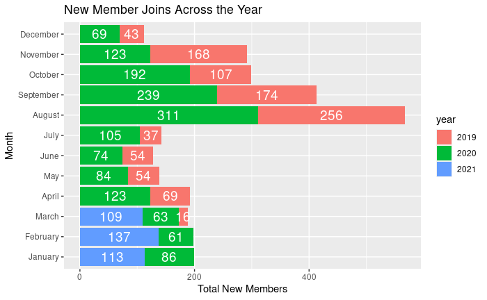

```r
all_joins = ggplot(data = agg_joins, mapping = aes(x = month, y = new_members, fill = year)) + xlab("Month") + ylab("Total New Members") + geom_col()+ geom_text(aes(label=new_members), position = position_stack(vjust= 0.5),
            colour = "white", size = 5) + coord_flip()
all_joins = all_joins + labs(title = "New Member Joins Across the Year")
all_joins
```

## all leaves

```r
leaves
```

| interval_start_timestamp | year | month | day | days_in_guild | leavers |
| --- | --- | --- | --- | --- | --- |
| 2019-03-29T00:00:00Z | 2019 | March | Friday | 'Members for 1 month+' | 1 |
| 2019-03-30T00:00:00Z | 2019 | March | Saturday | 'Members for 1 month+' | 1 |
| 2019-03-30T00:00:00Z | 2019 | March | Saturday | 'Members for < 1 month' | 1 |
| 2019-03-31T00:00:00Z | 2019 | March | Sunday | 'Members for 1 month+' | 2 |
| 2019-03-31T00:00:00Z | 2019 | March | Sunday | 'Members for < 1 month' | 1 |
| 2019-04-01T00:00:00Z | 2019 | April | Monday | 'Members for 1 month+' | 4 |
| 2019-04-02T00:00:00Z | 2019 | April | Tuesday | 'Members for 1 month+' | 1 |
| 2019-04-03T00:00:00Z | 2019 | April | Wednesday | 'Members for 1 month+' | 2 |
| 2019-04-03T00:00:00Z | 2019 | April | Wednesday | 'Members for < 1 month' | 2 |
| 2019-04-04T00:00:00Z | 2019 | April | Thursday | 'Members for 1 month+' | 2 |

[output cut: 990 more lines]

```r
agg_leaves.2019
```

| Months | Total Leavers |
| --- | --- |
| March | 6 |
| April | 75 |
| May | 54 |
| June | 45 |
| July | 47 |
| August | 66 |
| September | 90 |
| October | 60 |
| November | 118 |
| December | 43 |

```r
agg_leaves.2020
```

| Group.1 | x |
| --- | --- |
| January | 66 |
| February | 82 |
| March | 73 |
| April | 95 |
| May | 72 |
| June | 82 |
| July | 90 |
| August | 127 |
| September | 132 |
| October | 100 |

[output cut: 2 more lines]

```r
agg_leaves.2021
```

| Group.1 | x |
| --- | --- |
| January | 93 |
| February | 88 |
| March | 78 |

```r
agg_leaves
```

| month | year | leavers |
| --- | --- | --- |
| March | 2019 | 6 |
| April | 2019 | 75 |
| May | 2019 | 54 |
| June | 2019 | 45 |
| July | 2019 | 47 |
| August | 2019 | 66 |
| September | 2019 | 90 |
| October | 2019 | 60 |
| November | 2019 | 118 |
| December | 2019 | 43 |

[output cut: 15 more lines]

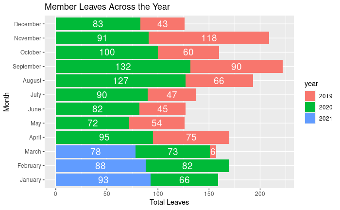

```r
all_leaves = ggplot(data = agg_leaves, mapping = aes(x = month, y = leavers, fill = year)) + xlab("Month") + ylab("Total Leaves") + geom_col()+ geom_text(aes(label=leavers), position = position_stack(vjust= 0.5),
            colour = "white", size = 5) + coord_flip()
all_leaves = all_leaves + labs(title = "Member Leaves Across the Year")

all_leaves
```

## all communicators

```r
communicators
```

| interval_start_timestamp | year | month | day | visitors | pct_communicated | total_communicated |
| --- | --- | --- | --- | --- | --- | --- |
| 2019-03-29T00:00:00Z | 2019 | March | Friday | 206 | 25.728155 | 53 |
| 2019-03-30T00:00:00Z | 2019 | March | Saturday | 184 | 20.652174 | 38 |
| 2019-03-31T00:00:00Z | 2019 | March | Sunday | 185 | 24.324324 | 45 |
| 2019-04-01T00:00:00Z | 2019 | April | Monday | 328 | 22.865854 | 75 |
| 2019-04-02T00:00:00Z | 2019 | April | Tuesday | 143 | 33.566434 | 48 |
| 2019-04-03T00:00:00Z | 2019 | April | Wednesday | 271 | 16.605166 | 45 |
| 2019-04-04T00:00:00Z | 2019 | April | Thursday | 381 | 13.385827 | 51 |
| 2019-04-05T00:00:00Z | 2019 | April | Friday | 190 | 24.736842 | 47 |
| 2019-04-06T00:00:00Z | 2019 | April | Saturday | 163 | 26.993865 | 44 |
| 2019-04-07T00:00:00Z | 2019 | April | Sunday | 159 | 31.446541 | 50 |

[output cut: 719 more lines]

```r
agg_comm.2019
```

| Months | Total Communicated |
| --- | --- |
| March | 136 |
| April | 1531 |
| May | 1238 |
| June | 1094 |
| July | 1150 |
| August | 1760 |
| September | 2588 |
| October | 2168 |
| November | 1861 |
| December | 1184 |

```r
agg_comm.2020
```

| Months | Total Communicated |
| --- | --- |
| January | 1094 |
| February | 1232 |
| March | 1174 |
| April | 1186 |
| May | 1077 |
| June | 1139 |
| July | 1071 |
| August | 1859 |
| September | 2175 |
| October | 1602 |

[output cut: 2 more lines]

```r
agg_comm.2021
```

| Months | Total Communicated |
| --- | --- |
| January | 968 |
| February | 948 |
| March | 876 |

```r
agg_comms
```

| month | year | total_communicated |
| --- | --- | --- |
| March | 2019 | 136 |
| April | 2019 | 1531 |
| May | 2019 | 1238 |
| June | 2019 | 1094 |
| July | 2019 | 1150 |
| August | 2019 | 1760 |
| September | 2019 | 2588 |
| October | 2019 | 2168 |
| November | 2019 | 1861 |
| December | 2019 | 1184 |

[output cut: 15 more lines]

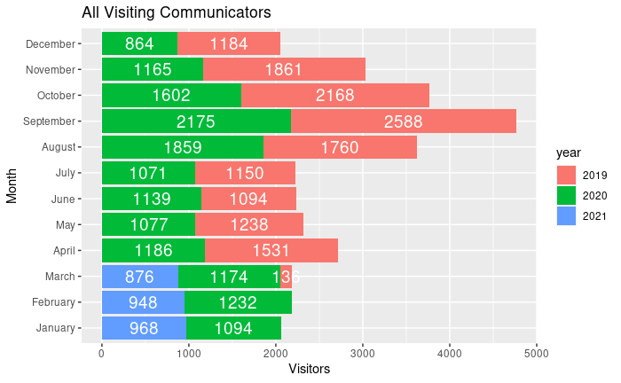

```r
all_comms = ggplot(data = agg_comms, mapping = aes(x = month, y = total_communicated, fill = year)) + xlab("Month") + ylab("Visitors") + geom_col()+ geom_text(aes(label=total_communicated), position = position_stack(vjust= 0.5),
            colour = "white", size = 5) + coord_flip()
all_comms = all_comms + labs(title = "All Visiting Communicators")

all_comms
```

# messing with top values

```r
# dataframe_name[with(dataframe_name, order(column_name)), ]
df=voice[with(voice,order("communicators")),]
df
```

|  | interval_start_timestamp | channel_name | channel_id | listeners | communicators |
| --- | --- | --- | --- | --- | --- |
| 1 | 2021-03-27T00:00:00+00:00 | AFK Channel | 2.559102e+17 | 7 | 0 |